# STAT 360: Computational Statistics and Data Analysis

## PS 1.4 - Marcus Haldane

### Load Relevant R Libraries

```r
library(rmarkdown); library(knitr); library(moments);
library(scatterplot3d); library(corrplot); library(pso)
library(psych); library(GPArotation); library(lavaan)
```

### Exercise 1.13 - Stock Portfolios

#### Part (a)

```r
# Insert code or written answer here
stockInfo <- matrix(c(3805, 4980, 42330, 468665, 0.354,
                      4980, 8239, 64715, 700917, 1.401,
                      42330, 64715, 559182, 6294123, 14.990,
                      468665, 700917, 6294123, 80834339, 249.131,
                      0.354, 1.401, 14.990, 249.131, 0.005), nrow = 5, ncol = 5, byrow = T,
                      dimnames = list(c("SOL","BNB","ETH","BTC","DOGE"), c("SOL","BNB","ETH","BTC","DOGE")))
stockInfo
```

```
##             SOL        BNB        ETH          BTC    DOGE
## SOL    3805.000   4980.000   42330.00   468665.000   0.354
## BNB    4980.000   8239.000   64715.00   700917.000   1.401
## ETH   42330.000  64715.000  559182.00  6294123.000  14.990
## BTC  468665.000 700917.000 6294123.00 80834339.000 249.131
## DOGE      0.354      1.401      14.99      249.131   0.005
```

#### Part (b)

```r
# Insert code or written answer here
n <- 365
SS <- stockInfo * (n - 1)
SS
```

```
##               SOL          BNB          ETH          BTC      DOGE
## SOL  1.385020e+06 1.812720e+06 1.540812e+07 1.705941e+08   128.856
## BNB  1.812720e+06 2.998996e+06 2.355626e+07 2.551338e+08   509.964
## ETH  1.540812e+07 2.355626e+07 2.035422e+08 2.291061e+09  5456.360
## BTC  1.705941e+08 2.551338e+08 2.291061e+09 2.942370e+10 90683.684
## DOGE 1.288560e+02 5.099640e+02 5.456360e+03 9.068368e+04     1.820
```

#### Part (c)

```r
# Insert code or written answer here
stockCor <- solve(sqrt(diag(diag(stockInfo)))) %*% stockInfo %*% t(solve(sqrt(diag(diag(stockInfo)))))
stockCor
```

```
##            [,1]      [,2]      [,3]      [,4]       [,5]
## [1,] 1.00000000 0.8894361 0.9176865 0.8450594 0.08115979
## [2,] 0.88943612 1.0000000 0.9534350 0.8588778 0.21828097
## [3,] 0.91768651 0.9534350 1.0000000 0.9361829 0.28349150
## [4,] 0.84505942 0.8588778 0.9361829 1.0000000 0.39187253
## [5,] 0.08115979 0.2182810 0.2834915 0.3918725 1.00000000
```

#### Part (d)

```r
# Written answer directly below
```

You may want to look at a scatter plot matrix before pursuing any further analyses using these matrices because of the presence of outliers in the data. Specifically, DOGE has a significantly weaker correlation with the rest of the crypto-currencies than the rest of the crypto-currencies have with each other. With DOGE being significanly different, numerical analysis alone might not grant a complete picture of the meaning behind the data.

### EXERCISE 1.14 - Presidential Approval Ratings and Margin of Victory (continued)

#### Part (a)

```r
# Insert code or written answer here
electionInfo <- matrix(c(1956, 68, 15.4,
                         1964, 74, 22.6,
                         1972, 59, 23.2,
                         1976, 45, -2.1,
                         1980, 37, -0.7,
                         1984, 58, 18.2,
                         1992, 35, -5.5,
                         1996, 54, 8.5,
                         2004, 48, 2.4,
                         2012, 52, 3.9,
                         2020, 45, -4.4), nrow = 11, ncol = 3, byrow = T,
                       dimnames =list(c("Eisenhower", "Johnson", "Nixon", "Ford", "Carter", "Reagan", "BushSr", "Clinton", "BushJr", "Obama", "Trump"), c("Year", "Approval", "Margin")))
electionInfo
```

```
##            Year Approval Margin
## Eisenhower 1956       68   15.4
## Johnson    1964       74   22.6
## Nixon      1972       59   23.2
## Ford       1976       45   -2.1
## Carter     1980       37   -0.7
## Reagan     1984       58   18.2
## BushSr     1992       35   -5.5
## Clinton    1996       54    8.5
## BushJr     2004       48    2.4
## Obama      2012       52    3.9
## Trump      2020       45   -4.4
```

#### Part (b)

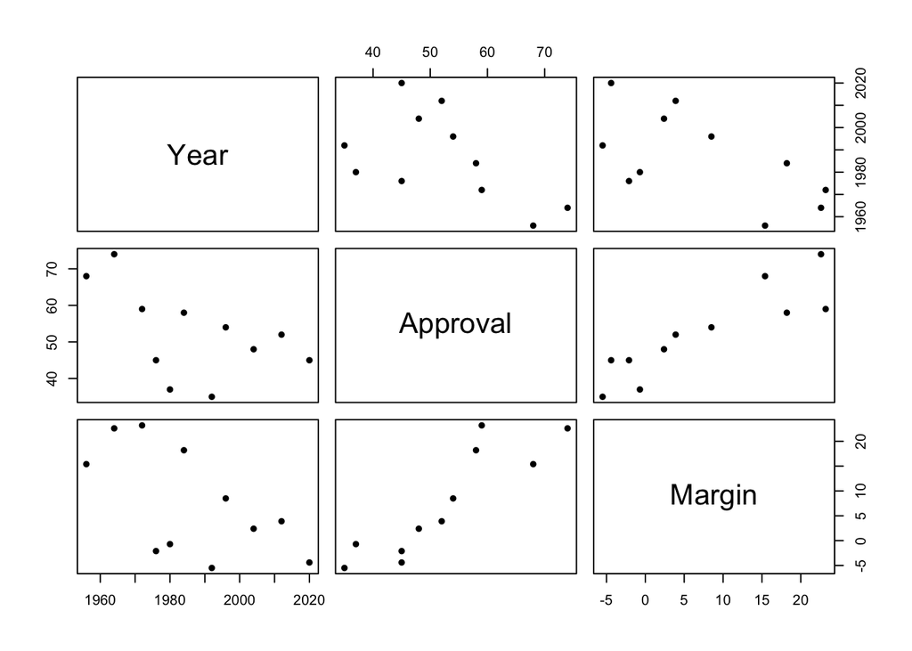

```r
# Insert code or written answer here
pairs(electionInfo, pch = 16)
```

#### Part (c)

```r
# Written answer directly below
```

The covariability between Year and the president’s Approval is negative because the greater values in the Year variable mainly correspond with the lesser values of the Approval variable, and the same holds for the lesser values in the Year variable, which mainly correspond with the greater values of the Approval variable.

#### Part (d)

```r
# Written answer directly below
```

From the scatter plot matrix above, the greatest covariability appears to be between the Approval and Margin variables. Those two variables seem to cluster along a line of best fit better than any other pair of variables.

#### Part (e)

```r
# Insert code or written answer here
cor(electionInfo)
```

```
##                Year   Approval     Margin
## Year      1.0000000 -0.5420676 -0.6132944
## Approval -0.5420676  1.0000000  0.8842433
## Margin   -0.6132944  0.8842433  1.0000000
```

#### Part (f)

```r
# Written answer directly below
```

As can be seen in the correlation matrix above, the correlation between the Approval and Margin variables is the furthest from 0, making that the strongest correlation. It is also a positive correlation, while the correlation between the Year and Approval variables is negative, as is the covariability of those variables as discussed in Part (c) of this exercise.

### EXERCISE 1.15 - Meet the Palmer Penguins

#### Part (a)

```r
# Insert code or written answer here
setwd("/Users/marcushaldane/Desktop/Projects/Coding/Fall-2023-workspace/STAT360/STAT360-Chapter1") # Navigate to Directory containing Penguins Data
penguins <- read.csv("penguins.csv") # Read in Ames Property Values Data
penguinsMatrix <- as.matrix(penguins) # Convert Ames Property Values DataFrame to Matrix
requiredColumns <- c("bill_length_mm","bill_depth_mm","flipper_length_mm","body_mass_g","year") # Create a list of columns which are needed for this exercise
penguinsMatrix <- penguinsMatrix[,requiredColumns] # Remove unneeded columns, leaving only the required columns
penguinsMatrix <- apply(penguinsMatrix, 2, as.numeric) # Convert to all data values from characters to numeric values
penguinsMatrix <- head(penguinsMatrix, 30) # Resize the matrix to match what is in the textbook
penguinsMatrix
```

```
##       bill_length_mm bill_depth_mm flipper_length_mm body_mass_g year
##  [1,]           39.1          18.7               181        3750 2007
##  [2,]           39.5          17.4               186        3800 2007
##  [3,]           40.3          18.0               195        3250 2007
##  [4,]             NA            NA                NA          NA 2007
##  [5,]           36.7          19.3               193        3450 2007
##  [6,]           39.3          20.6               190        3650 2007
##  [7,]           38.9          17.8               181        3625 2007
##  [8,]           39.2          19.6               195        4675 2007
##  [9,]           34.1          18.1               193        3475 2007
## [10,]           42.0          20.2               190        4250 2007
## [11,]           37.8          17.1               186        3300 2007
## [12,]           37.8          17.3               180        3700 2007
## [13,]           41.1          17.6               182        3200 2007
## [14,]           38.6          21.2               191        3800 2007
```

[output cut: 16 more lines]

#### Part (b)

```r
# Insert code or written answer here
cor(penguinsMatrix, use = "pairwise.complete.obs")
```

```
## Warning in cor(penguinsMatrix, use = "pairwise.complete.obs"): the standard
## deviation is zero
```

```
##                   bill_length_mm bill_depth_mm flipper_length_mm body_mass_g
## bill_length_mm        1.00000000     0.2683562        0.09149793   0.2478050
## bill_depth_mm         0.26835620     1.0000000        0.56931342   0.5980284
## flipper_length_mm     0.09149793     0.5693134        1.00000000   0.4683793
## body_mass_g           0.24780496     0.5980284        0.46837930   1.0000000
## year                          NA            NA                NA          NA
##                   year
## bill_length_mm      NA
## bill_depth_mm       NA
## flipper_length_mm   NA
## body_mass_g         NA
## year                NA
```

#### Part (c)

```r
# Written answer directly below
```

Attempting to find the correlation matrix for the penguin data stored in penguinsMatrix yields the following warning:

Warning: the standard deviation is zero

This warning comes about because there are only year values from 2007 in the penguinsMatrix. As a result, the deviation of each data point in the Year column is zero [(Xi - Xbar)^2 = (2007 - 2007)^2 = 0^2 = 0 for all datapoints]. Consequently, the sum of squares will also be zero, and therefore standard deviation will be calculated as (0/30-1), which is also zero. This is why the warning comes about, and the consequence of having zero as a standard deviation is that for each of the correlations involving year, the covariability of some arbitrary variable and the Year variable will be divided by product of the standard deviation of that arbitrary variable and the standard deviation of the Year variable, which is zero. Dividing by zero is undefined, and therefore the correlation matrix can only populate the correlations involving the Year variable with “NA”.

#### Part (d)

```r
# Insert code or written answer here
cor(penguinsMatrix[,c("bill_length_mm","bill_depth_mm","flipper_length_mm","body_mass_g")], use = "pairwise.complete.obs")
```

```
##                   bill_length_mm bill_depth_mm flipper_length_mm body_mass_g
## bill_length_mm        1.00000000     0.2683562        0.09149793   0.2478050
## bill_depth_mm         0.26835620     1.0000000        0.56931342   0.5980284
## flipper_length_mm     0.09149793     0.5693134        1.00000000   0.4683793
## body_mass_g           0.24780496     0.5980284        0.46837930   1.0000000
```

### EXERCISE 1.16 - Residential Property Value in Ames, IA

#### Part (a)

```r
# Insert code or written answer here
setwd("/Users/marcushaldane/Desktop/Projects/Coding/Fall-2023-workspace/STAT360/STAT360-Chapter1") # Navigate to Directory containing Ames Property Values Data
amesProperties <- read.csv("ames.csv") # Read in Ames Property Values Data
amesMatrix <- as.matrix(amesProperties) # Convert Ames Property Values DataFrame to Matrix
amesRowNames <- c(amesMatrix[,"PID"]) # Get a list of the RowNames
amesColumnNames <- c("Area",    "Price",    "Subclass", "Lot Frontage", "Lot Area", "Quality",  "Built",    "Remodel") # Create a list of column names
amesRequiredColumns <- c("area", "price", "MS.SubClass", "Lot.Frontage", "Lot.Area", "Overall.Qual", "Year.Built", "Year.Remod.Add") # Create a list of columns which are needed for this exercise
amesMatrix <- amesMatrix[,amesRequiredColumns] # Remove unneeded columns, leaving only the required columns
amesMatrix <- matrix(as.numeric(amesMatrix), ncol = ncol(amesMatrix)) # Convert to all data values from characters to numeric values
rownames(amesMatrix) <- amesRowNames # Apply row names
colnames(amesMatrix) <- amesColumnNames # Apply column names
amesMatrix <- head(amesMatrix, 20) # Resize the matrix to match what is in the textbook
amesMatrix
```

```
##            Area  Price Subclass Lot Frontage Lot Area Quality Built Remodel
##  526301100 1656 215000       20          141    31770       6  1960    1960
##  526350040  896 105000       20           80    11622       5  1961    1961
##  526351010 1329 172000       20           81    14267       6  1958    1958
##  526353030 2110 244000       20           93    11160       7  1968    1968
##  527105010 1629 189900       60           74    13830       5  1997    1998
##  527105030 1604 195500       60           78     9978       6  1998    1998
##  527127150 1338 213500      120           41     4920       8  2001    2001
##  527145080 1280 191500      120           43     5005       8  1992    1992
##  527146030 1616 236500      120           39     5389       8  1995    1996
##  527162130 1804 189000       60           60     7500       7  1999    1999
##  527163010 1655 175900       60           75    10000       6  1993    1994
##  527165230 1187 185000       20           NA     7980       6  1992    2007
##  527166040 1465 180400       60           63     8402       6  1998    1998
##  527180040 1341 171500       20           85    10176       7  1990    1990
##  527182190 1502 212000      120           NA     6820       8  1985    1985
##  527216070 3279 538000       60           47    53504       8  2003    2003
##  527225035 1752 164000       50          152    12134       8  1988    2005
##  527258010 1856 394432       20           88    11394       9  2010    2010
##  527276150  864 141000       20          140    19138       4  1951    1951
##  527302110 2073 210000       20           85    13175       6  1978    1988
```

#### Part (b)

```r
# Insert code or written answer here
amesCorMatrix <- cor(amesMatrix, use = "pairwise.complete.obs")
amesCorMatrix
```

```
##                      Area       Price     Subclass Lot Frontage    Lot Area
## Area          1.000000000  0.83669707  0.009877884   -0.1903849  0.65356928
## Price         0.836697072  1.00000000  0.060657411   -0.2793401  0.66298135
## Subclass      0.009877884  0.06065741  1.000000000   -0.6580910 -0.27953152
## Lot Frontage -0.190384890 -0.27934008 -0.658091006    1.0000000  0.17614738
## Lot Area      0.653569280  0.66298135 -0.279531522    0.1761474  1.00000000
## Quality       0.437179617  0.55742029  0.495550404   -0.3490174 -0.04666484
## Built         0.384741065  0.45425352  0.474425794   -0.5766505 -0.12934526
## Remodel       0.367422771  0.38401187  0.386579652   -0.4490113 -0.15246399
##                  Quality      Built    Remodel
## Area          0.43717962  0.3847411  0.3674228
## Price         0.55742029  0.4542535  0.3840119
## Subclass      0.49555040  0.4744258  0.3865797
## Lot Frontage -0.34901740 -0.5766505 -0.4490113
## Lot Area     -0.04666484 -0.1293453 -0.1524640
## Quality       1.00000000  0.5966431  0.5715424
## Built         0.59664312  1.0000000  0.9580094
## Remodel       0.57154244  0.9580094  1.0000000
```

#### Part (c)

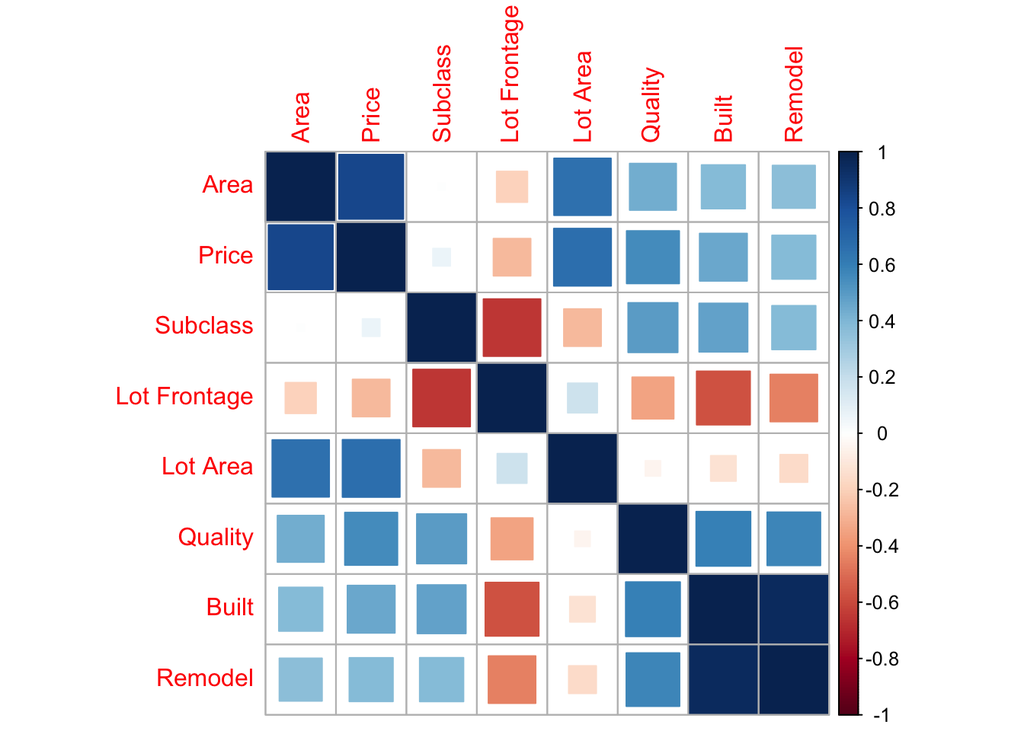

```r
# Insert code or written answer here
corrplot(amesCorMatrix, method = "square")
```

#### Part (d)

```r
# Insert code or written answer here
amesCorMatrix2 <- cor(amesMatrix, use = "complete.obs")
amesCorMatrix2
```

```
##                      Area       Price     Subclass Lot Frontage    Lot Area
## Area          1.000000000  0.84091297 -0.006886259   -0.1903849  0.64697767
## Price         0.840912968  1.00000000  0.056563814   -0.2793401  0.66544380
## Subclass     -0.006886259  0.05656381  1.000000000   -0.6580910 -0.27911243
## Lot Frontage -0.190384890 -0.27934008 -0.658091006    1.0000000  0.17614738
## Lot Area      0.646977673  0.66544380 -0.279112429    0.1761474  1.00000000
## Quality       0.451272582  0.57253639  0.438665723   -0.3490174 -0.02946607
## Built         0.410903696  0.46388101  0.554920363   -0.5766505 -0.12329332
## Remodel       0.435994206  0.41693505  0.516457681   -0.4490113 -0.13478802
##                  Quality      Built    Remodel
## Area          0.45127258  0.4109037  0.4359942
## Price         0.57253639  0.4638810  0.4169350
## Subclass      0.43866572  0.5549204  0.5164577
## Lot Frontage -0.34901740 -0.5766505 -0.4490113
## Lot Area     -0.02946607 -0.1232933 -0.1347880
## Quality       1.00000000  0.6331902  0.6508428
## Built         0.63319022  1.0000000  0.9704787
## Remodel       0.65084285  0.9704787  1.0000000
```

#### Part (e)

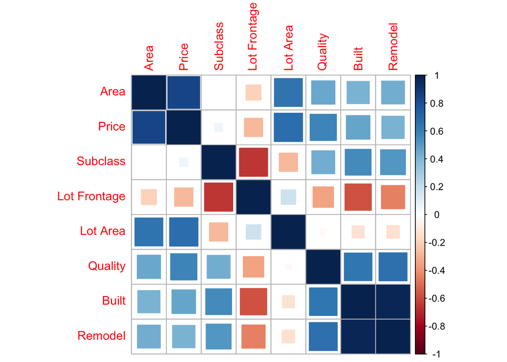

```r
# Insert code or written answer here
corrplot(amesCorMatrix2, method = "square")
```

#### Part (f)

```r
# Written answer directly below
```

The differences between these two correlation matricies are minimal to the point of being undetectable to my eye, but some very slight differences can be noticed when viewing the two correlation plots. Take the correlation between the Subclass variable and the Quality variable. In the pairwise complete correlation plot, that square is slightly larger and darker than the corresponding square in the complete correlation plot. The opposite pattern can be noticed with the Subclass variable and the Built variable, as well as the Subclass variable and the Remodel variable. In each of those cases, the pairwise complete correlation plot, that square is slightly smaller and lighter than the corresponding square in the complete correlation plot.